# PortfolioTitanicProj

### Project Titanic Kaggle Challenge

Task: Design and implement a machine learning classification pipeline for the Titanic Kaggle challenge. The objective is to accurately predict the survival outcome of Titanic passengers based on various attributes like age, sex, passenger class, etc. The dataset provided consists of training and test sets derived from historical records of actual Titanic passengers, detailing attributes such as ticket class, sex, age, and fare. The challenge involves preprocessing the data, selecting relevant features, and building a predictive model that can determine, given certain attributes of a passenger, whether they would have survived the disaster.

### Exploring Data

```python
import pandas as pd
import matplotlib.pyplot as plt
import seaborn as sns
import warnings
warnings.filterwarnings('ignore')
from sklearn import preprocessing
from sklearn.ensemble import RandomForestClassifier
from sklearn.model_selection import train_test_split, GridSearchCV
from sklearn.metrics import accuracy_score
from sklearn.preprocessing import MinMaxScaler
from sklearn.svm import SVC

# Load datasets: The primary step for any data analysis is to load the datasets.
data = pd.read_csv('train.csv')
test_data = pd.read_csv('test.csv')

# Combining train and test data: This is useful for exploratory data analysis (EDA)
# and ensures consistency in data preprocessing steps across both datasets.
combined_data_for_exploring = pd.concat([data, test_data], ignore_index=True)  # ignore_index ensures a continuous index for the combined dataset.

# Print column names: Knowing attribute names gives an overview of the dataset's structure.
print("Attributes (Column Names):")
print(combined_data_for_exploring.columns)  # Only display column names rather than the entire combined dataset.

# Checking for missing values: Identifying columns with missing values is crucial because
# machine learning models can't handle NaN values without preprocessing.
print("\nMissing Data:")
missing_data = combined_data_for_exploring.isnull().sum()
print(missing_data)

# Display data types: Understanding data types assists in determining appropriate preprocessing methods
# and helps identify any discrepancies (e.g., a numerical feature encoded as a string).
print("\nData Types:")
print(combined_data_for_exploring.dtypes)

# Statistical summary: Provides insights into the distribution and characteristics of numerical attributes.
# It's a quick way to identify outliers or anomalies.
print("\nStatistical Summary:")
print(combined_data_for_exploring.describe())
```

```
Attributes (Column Names):
Index(['PassengerId', 'Survived', 'Pclass', 'Name', 'Sex', 'Age', 'SibSp',
       'Parch', 'Ticket', 'Fare', 'Cabin', 'Embarked'],
      dtype='object')

Missing Data:
PassengerId       0
Survived        418
Pclass            0
Name              0
Sex               0
Age             263
SibSp             0
Parch             0
Ticket            0
Fare              1
Cabin          1014
Embarked          2
dtype: int64

Data Types:
PassengerId      int64
Survived       float64
Pclass           int64
Name            object
Sex             object
Age            float64
SibSp            int64
Parch            int64
Ticket          object
Fare           float64
Cabin           object
Embarked        object
dtype: object

Statistical Summary:
       PassengerId    Survived       Pclass          Age        SibSp  \
count  1309.000000  891.000000  1309.000000  1046.000000  1309.000000
mean    655.000000    0.383838     2.294882    29.881138     0.498854
std     378.020061    0.486592     0.837836    14.413493     1.041658
min       1.000000    0.000000     1.000000     0.170000     0.000000
25%     328.000000    0.000000     2.000000    21.000000     0.000000
50%     655.000000    0.000000     3.000000    28.000000     0.000000
75%     982.000000    1.000000     3.000000    39.000000     1.000000
max    1309.000000    1.000000     3.000000    80.000000     8.000000

             Parch         Fare
count  1309.000000  1308.000000
mean      0.385027    33.295479
std       0.865560    51.758668
min       0.000000     0.000000
25%       0.000000     7.895800
50%       0.000000    14.454200
75%       0.000000    31.275000
max       9.000000   512.329200
```

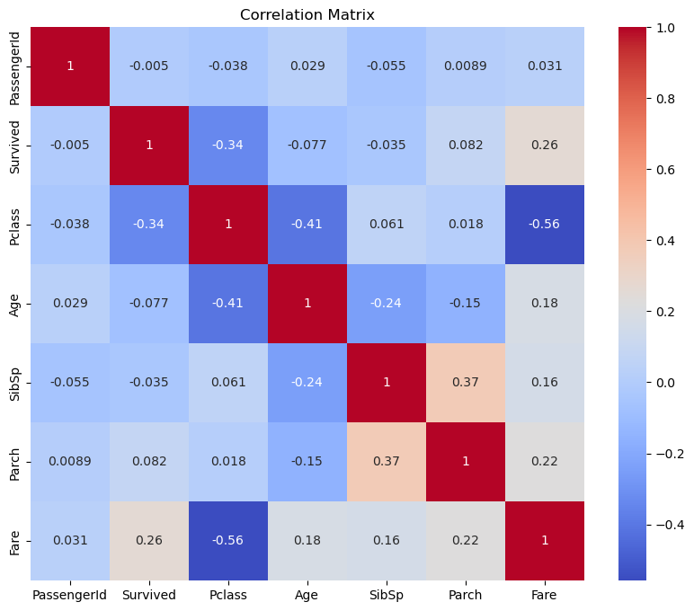

```python
# Calculate the correlation matrix: Correlations give insights into relationships between variables.
# A high positive or negative correlation might indicate potential multicollinearity or a strong relationship, respectively.
correlation_matrix = combined_data_for_exploring.corr()

# Create a heatmap: A heatmap is a graphical representation where individual values are represented as colors.
# It's a way to visualize the correlation matrix and quickly identify highly correlated variables.
plt.figure(figsize=(10, 8))  # Setting a bigger plot size for better clarity.
sns.heatmap(correlation_matrix, annot=True, cmap='coolwarm', square=True)  # `annot=True` ensures values are displayed on the heatmap, and `cmap` sets the color scheme.

# Set the title for the plot: Providing a title gives context to viewers about the plot's content.
plt.title('Correlation Matrix')

# Display the heatmap: This renders the figure and visually presents the correlations between variables.
plt.show()
```

Based on initial analysis, next step is to clean up data:

1. Fill in missing values for Fare and Embarked
2. Drop PassengerId, Ticket
3. Create new feature "Title" and get average age for each title
4. Fill in missing values for Age based on Title where applicable
5. Re-evaluate important features after values imputed
6. Important features for prediction - Fare, Parch, SibSp, Age, PClass

```python
# Extract titles from the 'Name' column: Titles (like Mr, Mrs) can provide additional information about
# socio-economic status, age, marital status, etc., which might be useful for data imputation or feature engineering.
combined_data_for_exploring['Title'] = combined_data_for_exploring['Name'].str.extract(' ([A-Za-z]+)\.', expand=False)

# Aggregate age data by title: Knowing the average age and count for each title can help
# in understanding age distributions across titles and can be useful for imputing missing ages.
title_stats = combined_data_for_exploring.groupby('Title')['Age'].agg(['mean', 'count'])
print(title_stats)

# Impute missing age values based on title: Instead of filling missing ages with a general mean or median,
# using the mean age of a person's title can provide a more accurate estimation.
title_ages = combined_data_for_exploring.groupby('Title')['Age'].mean()
combined_data_for_exploring['Age'] = combined_data_for_exploring.apply(
    lambda row: title_ages[row['Title']] if pd.isnull(row['Age']) and row['Title'] in title_ages else row['Age'],
    axis=1
)

# Handle any residual missing age values: In case some titles don't have an associated average age,
# we fill with the overall mean age of the dataset.
combined_data_for_exploring['Age'].fillna(combined_data_for_exploring['Age'].mean(), inplace=True)

# Impute missing fare values: Fare is an important feature, and missing values can be filled
# with the median, which is robust to outliers, to ensure no data is missing in this column.
combined_data_for_exploring["Fare"].fillna(combined_data_for_exploring["Fare"].median(), inplace=True)
```

```
               mean  count
Title
Capt      70.000000      1
Col       54.000000      4
Countess  33.000000      1
Don       40.000000      1
Dona      39.000000      1
Dr        43.571429      7
Jonkheer  38.000000      1
Lady      48.000000      1
Major     48.500000      2
Master     5.482642     53
Miss      21.774238    210
Mlle      24.000000      2
Mme       24.000000      1
Mr        32.252151    581
Mrs       36.994118    170
Ms        28.000000      1
Rev       41.250000      8
Sir       49.000000      1
```

```python
# Extract the first letter of the 'Cabin' column: The first letter in the 'Cabin' value refers to the deck on the Titanic.
# Different decks might have different survival rates due to factors like proximity to lifeboats, structural integrity, etc.
combined_data_for_exploring['cabin_adv'] = combined_data_for_exploring.Cabin.apply(lambda x: str(x)[0])

# Print count of each unique cabin letter: This provides an overview of how many passengers were on each deck.
print("Passenger count by cabin deck:")
print(combined_data_for_exploring.cabin_adv.value_counts())

# Compare survival rates by cabin: Using a pivot table allows us to see the distribution of survived vs. not-survived
# across different decks, which could provide insights into which decks were more "fortunate" during the disaster.
survival_by_cabin = pd.pivot_table(combined_data_for_exploring, index='Survived', columns='cabin_adv', values='Name', aggfunc='count')
print("\nSurvival rates by cabin deck:")
print(survival_by_cabin)
```

```
Passenger count by cabin deck:
n    1014
C      94
B      65
D      46
E      41
A      22
F      21
G       5
T       1
Name: cabin_adv, dtype: int64

Survival rates by cabin deck:
cabin_adv    A     B     C     D     E    F    G    T      n
Survived
0.0        8.0  12.0  24.0   8.0   8.0  5.0  2.0  1.0  481.0
1.0        7.0  35.0  35.0  25.0  24.0  8.0  2.0  NaN  206.0
```

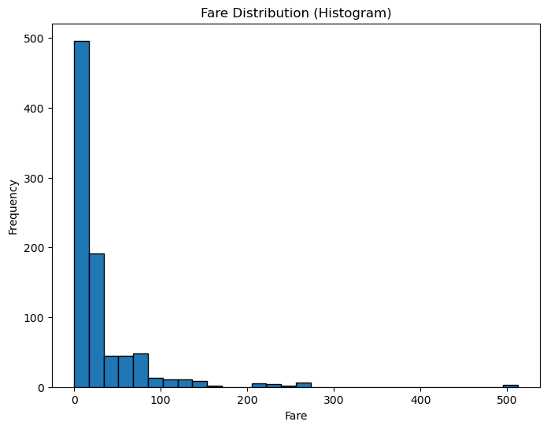

```python
# Create a histogram to visualize the distribution of the 'Fare' feature:
# Histograms are effective for understanding the distribution of a single numerical variable.
# By visualizing the fare distribution, we can gain insights into the range of fares
# passengers paid and how many passengers paid within certain fare brackets.

# Setting up the figure size for clarity
plt.figure(figsize=(8, 6))

# Plotting the histogram for 'Fare' with 30 bins to get a detailed distribution view.
# The edgecolor 'black' provides clear separation between bars.
plt.hist(data['Fare'], bins=30, edgecolor='black')

# Labeling the axes for better interpretability
plt.xlabel('Fare')
plt.ylabel('Frequency')

# Providing a title for context
plt.title('Fare Distribution (Histogram)')

# Displaying the histogram
plt.show()
```

### Cleaning Up Data

```python
def extract_title(name):
    """
    Extract the title (e.g., Mr, Mrs, Miss) from a name string.

    Parameters:
    - name: str, full name of the passenger

    Returns:
    - title: str, extracted title from the name
    """
    return name.split(',')[1].split('.')[0].strip()

def clean(data):
    """
    Preprocess and clean the Titanic dataset for modeling.

    Steps involved:
    - Handle missing values in various columns
    - Extract titles from names for potential feature engineering
    - Drop unnecessary columns

    Parameters:
    - data: DataFrame, raw Titanic dataset

    Returns:
    - data: DataFrame, cleaned and preprocessed dataset
    """

    # 'Fare' might be crucial for predictions. The median is chosen because it's less sensitive to outliers than the mean.
    data["Fare"].fillna(data["Fare"].median(), inplace=True)

    # Titles can potentially provide hints about socio-economic status, age, etc., which could be useful for imputing missing ages or other feature engineering.
    data['Title'] = data['Name'].apply(extract_title)

    # Instead of filling missing ages with a general mean, using the mean age of a person's title can provide a more accurate estimation.
    title_ages = data.groupby('Title')['Age'].mean()
    data['Age'] = data.apply(
        lambda row: title_ages[row['Title']] if pd.isnull(row['Age']) and row['Title'] in title_ages else row['Age'],
        axis=1
    )

    # Handle residual missing age values with the overall mean of the dataset.
    data['Age'].fillna(data['Age'].mean(), inplace=True)

    # 'Embarked' is a categorical feature. 'U' denotes an Unknown embarkation point. It helps handle NaNs without dropping rows.
    data.Embarked.fillna("U", inplace=True)

    # Cabin letter might indicate deck, which could be related to survival rates. 'N' denotes an Unknown cabin.
    data['Cabin'] = data['Cabin'].str.extract(r'([A-Za-z])')
    data.Cabin.fillna("N", inplace=True)

    # Drop columns that might not provide direct valuable predictive information, or are redundant after feature extraction.
    data = data.drop(["Ticket", "Name", "Title", "PassengerId"], axis=1)

    return data
```

```python
def main():
    # Load datasets: Essential first step to access the data and perform transformations.
    data = pd.read_csv("train.csv")
    test = pd.read_csv("test.csv")

    # Retaining the 'PassengerId' from the test set for the final submission.
    test_ids = test["PassengerId"]

    # Preprocess and clean data: Ensures that data is in a suitable format and missing values are handled.
    data = clean(data)
    test = clean(test)

    # Encode categorical features: Machine learning models require numerical input, so categories need encoding.
    le = preprocessing.LabelEncoder()
    cols = ["Sex", "Embarked", "Cabin"]
    for col in cols:
        data[col] = le.fit_transform(data[col])  # Fit the encoder and transform training data.
        test[col] = le.transform(test[col])      # Use the same encoder to transform test data.
        print(f"Encoded classes for {col}:", le.classes_)

    # Splitting the data into features and target variable.
    y = data["Survived"]
    X = data.drop("Survived", axis=1)

    # Creating training and validation sets to evaluate model performance.
    X_train, X_val, y_train, y_val = train_test_split(X, y, test_size=0.2, random_state=42)

    # Initialize and train a basic Random Forest model.
    model_rf = RandomForestClassifier()
    model_rf.fit(X_train, y_train)

    # Hyperparameter tuning: Helps in optimizing the model for better performance.
    param_grid = {
        'n_estimators': [100, 200, 300],
        'max_depth': [3, 5, None],
        'min_samples_split': [2, 4, 6],
        'max_features': ['sqrt', 'log2', None]
    }

    grid_search = GridSearchCV(estimator=model_rf, param_grid=param_grid, cv=5)
    grid_search.fit(X_train, y_train)
    best_model = grid_search.best_estimator_
    print("Best Hyperparameters:", grid_search.best_params_)

    # Fit the best model and predict on validation set.
    best_model.fit(X_train, y_train)
    predictions = best_model.predict(X_val)
    accuracy = accuracy_score(y_val, predictions)
    print("Validation Accuracy (Random Forest):", accuracy)

    # Predict on the actual test set.
    test_predictions = best_model.predict(test)

    # Prepare predictions for submission.
    submission_df = pd.DataFrame({"PassengerId": test_ids, "Survived": test_predictions})

    # Save the predictions to a CSV file for submission.
    submission_df.to_csv("submissionRF.csv", index=False)

if __name__ == "__main__":
    main()
```

```
Encoded classes for Sex: ['female' 'male']
Encoded classes for Embarked: ['C' 'Q' 'S' 'U']
Encoded classes for Cabin: ['A' 'B' 'C' 'D' 'E' 'F' 'G' 'N' 'T']
Best Hyperparameters: {'max_depth': 5, 'max_features': 'log2', 'min_samples_split': 6, 'n_estimators': 200}
Validation Accuracy (Random Forest): 0.8156424581005587
```

### Summary of the Project

##### Objective:

The primary goal of this project was to predict whether a passenger aboard the Titanic survived the tragic event. We used historical data about passengers, including details like age, cabin, ticket fare, and more, to build a predictive model.

##### Implementation Overview:

1. Data Loading and Exploration:  
   The data was loaded from two CSV files: one containing training data (train.csv) and the other with test data (test.csv). For exploratory data analysis (EDA), we combined both datasets to gain comprehensive insights. We examined the data's structure, missing values, and datatype of each feature.
2. Feature Engineering:  
   Titles were extracted from passenger names (like Mr, Mrs, Miss) as they can provide insights into a person's socio-economic status, age, marital status, etc. The first letter of the cabin value, representing the deck, was isolated since different decks might have different survival rates.
3. Data Cleaning and Preprocessing:  
   Missing fares were filled with the median fare, a robust measure compared to the mean. Ages were ingeniously imputed based on the extracted titles. If an age was missing for a 'Mr', it was filled with the average age of all 'Mr's in the dataset. Residual missing ages were filled using the overall mean age. Missing values in 'Embarked' were filled with a placeholder ('U' for Unknown). Irrelevant columns like 'Ticket', 'Name', and 'Title' were dropped to streamline the dataset.
4. Categorical Encoding:  
   Machine learning models require numerical input, so categorical columns like 'Sex', 'Embarked', and 'Cabin' were encoded into numerical values using label encoding.
5. Model Selection – Why Random Forest?  
   Random Forest was chosen as the predictive model for several reasons:  
   Handling Categorical Features: Random Forest can manage categorical variables without explicit one-hot encoding.  
   Model Interpretability: It offers feature importance, which helps in understanding which attributes significantly influence predictions.  
   Performance: Random Forest generally performs well on classification tasks and can capture complex non-linear relationships without much hyperparameter tuning.  
   Overfitting: With a proper configuration, Random Forest can be less prone to overfitting compared to simple decision trees.
6. Model Training and Hyperparameter Tuning:  
   An initial Random Forest model was trained. GridSearchCV was used for hyperparameter tuning to optimize the model's performance. Parameters like the number of estimators, max depth, min samples split, and max features were explored. The best model parameters were chosen based on cross-validation results.
7. Evaluation:  
   The model's predictions on the validation set were evaluated using accuracy as the metric.
8. Test Predictions and Submission:  
   The final optimized model was used to make predictions on the test set. Results were saved into a CSV file, ready for submission.

#### Key Concepts and Technologies Utilized

1. Pandas: Data manipulation and analysis.
2. Matplotlib & Seaborn: Data visualization (histograms, heatmaps).
3. Feature Engineering: Extracting titles from names and deck info from cabins.
4. Data Cleaning: Handling missing data and encoding categorical features.
5. Scikit-learn: RandomForestClassifier: Model choice for prediction.  
   train_test_split: Splitting datasets.  
   GridSearchCV: Hyperparameter tuning.  
   LabelEncoder: Converting categories to numbers.
6. Python Programming: Using built-in functions and constructs.
7. Machine Learning Concepts: Supervised learning, classification, model validation.
8. Domain Knowledge: Recognizing potential relevance of features based on historical context.